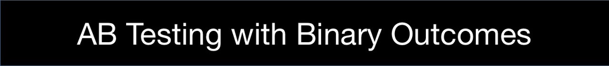

### Introduction

Small modifications to a webpage can greatly impact user behavior. But an experiment must be conducted to test the effectiveness of such changes. Visitors can be randomly assigned to view different versions of a webpage, and the behavior of the different groups can then be compared on some measure. This is known as AB testing.

### Define The Problem

An anti-pollution organization wants to test the effectiveness of a new webpage where visitors can sign up for their email newsletter. They suspect that the current page does not invoke enough imagery related to nature and pollution, leading to subpar *conversion rates*. The AB test will determine whether different versions of the webpage produce different conversion rates—beyond what would be expected by random chance.

The current sign-up page consists of a maple leaf on a white background. There are 2 new sign-up pages—one that consists of a lush green park, and another that consists of trash pollutants, each of which invokes imagery related to purity and pollution, respectively.

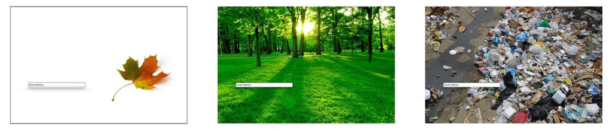

### Test Design

The next 600 visitors to the sign-up page are randomly assigned to view one of the three versions. For each visitor two pieces of information are recorded—the version of the webpage, and whether or not the visitor signed up.

### Statistics

The following statistics are used for the analysis:

1. Chi-Square Test of Equal Proportions
2. Bonferonni Pairwise Comparisons
3. Power Analysis for Chi-Square Tests
4. Logistic Regression

### Libraries

The `dplyr` package is used for data manipulation and the `ggplot2` package is used for graphing.

```r
library(dplyr); library(ggplot2)
```

### Simulating Data

For each group viewing the different webpages, 200 observations are sampled from a binomial distribution with `rbinom()`. The first input parameter corresponds to the number of observations, the second corresponds to the number of trials, and the third corresponds to the probability rate, or in this case the conversion rate. Each time the function is called, a different sample is obtained, thus conversion rates will most likely differ with each call. But on average, the sampled conversion rate will equal the proportion specified in the third input parameter.

```r
bi_dist_orig <- data_frame(signup=rbinom(200, 1, .22))

bi_dist_pollu <- data_frame(signup=rbinom(200, 1, .28))

bi_dist_natur <- data_frame(signup=rbinom(200, 1, .42))
```

Below is output from the code above. It is hard coded for replication purposes. Run the code below to replicate my results exactly. Otherwise skip the code below to maintain the random sample generated by the code above.

```r
bi_dist_orig <- data_frame(signup=c(0,  0,  0,  0,  0,  0,  0,  0,  0,  0,  0,  0,  0,  0,  1,  0,  1,  0,  0,  1,  1,  0,  0,  0,  0,  1,  0,  0,  1,  1,  0,  0,  1,  0,  0,  0,  0,  1,  0,  0,  0,  1,  0,  0,  0,  0,  0,  1,  0,  0,  1,  1,  0,  0,  1,  0,  0,  0,  0,  0,  1,  0,  0,  0,  0,  0,  0,  1,  1,  1,  1,  0,  0,  0,  0,  0,  1,  0,  0,  0,  0,  0,  0,  0,  0,  0,  0,  0,  0,  0,  1,  0,  0,  0,  1,  0,  0,  0,  1,  0,  0,  0,  0,  0,  0,  1,  1,  0,  0,  0,  0,  0,  0,  0,  0,  0,  0,  0,  0,  0,  0,  0,  0,  0,  0,  0,  0,  0,  0,  0,  0,  1,  0,  0,  0,  1,  0,  0,  0,  0,  1,  1,  0,  1,  1,  0,  0,  0,  0,  0,  1,  0,  1,  0,  0,  0,  0,  0,  0,  1,  0,  0,  1,  0,  0,  0,  0,  0,  0,  0,  1,  0,  1,  0,  1,  0,  0,  0,  0,  0,  0,  0,  1,  1,  1,  0,  0,  0,  0,  1,  1,  0,  1,  0,  0,  0,  0,  1,  1,  0))

bi_dist_pollu <- data_frame(signup=c(1, 0,  1,  0,  0,  0,  1,  1,  0,  0,  0,  0,  0,  0,  1,  0,  1,  0,  0,  0,  0,  0,  0,  1,  0,  0,  1,  1,  1,  1,  0,  0,  1,  0,  1,  0,  0,  1,  0,  1,  0,  0,  0,  1,  1,  0,  1,  0,  0,  1,  0,  0,  1,  1,  0,  0,  0,  0,  0,  0,  0,  0,  0,  0,  0,  0,  1,  1,  0,  1,  0,  0,  0,  1,  0,  1,  0,  0,  0,  0,  0,  0,  1,  0,  0,  1,  1,  1,  0,  0,  0,  0,  1,  1,  1,  0,  0,  0,  0,  0,  0,  0,  0,  1,  1,  1,  1,  1,  1,  1,  0,  0,  0,  1,  0,  0,  0,  0,  0,  0,  0,  1,  0,  1,  0,  0,  0,  0,  0,  0,  0,  0,  1,  0,  0,  0,  0,  0,  0,  0,  0,  0,  1,  1,  0,  0,  0,  0,  1,  0,  0,  0,  0,  1,  0,  1,  1,  0,  0,  0,  0,  0,  1,  0,  0,  0,  0,  0,  0,  0,  0,  0,  0,  1,  0,  0,  0,  0,  1,  0,  1,  0,  1,  0,  0,  1,  0,  1,  1,  0,  0,  1,  0,  0,  0,  0,  0,  0,  0,  0))

bi_dist_natur <- data_frame(signup=c(0, 1,  0,  0,  1,  1,  0,  1,  1,  0,  0,  0,  0,  0,  0,  0,  0,  1,  0,  1,  1,  1,  0,  0,  0,  1,  1,  0,  0,  1,  1,  0,  1,  0,  0,  0,  0,  0,  0,  0,  0,  0,  0,  0,  1,  0,  0,  0,  1,  0,  0,  1,  0,  1,  0,  1,  1,  0,  1,  1,  0,  0,  1,  0,  1,  0,  1,  0,  1,  1,  1,  1,  1,  0,  0,  1,  0,  0,  1,  0,  0,  1,  1,  0,  0,  0,  1,  1,  1,  1,  0,  1,  1,  1,  0,  1,  0,  1,  0,  0,  1,  0,  0,  0,  1,  1,  0,  0,  1,  1,  1,  0,  1,  1,  1,  1,  0,  0,  0,  1,  0,  1,  1,  0,  0,  1,  0,  0,  0,  1,  1,  0,  0,  1,  1,  0,  0,  0,  1,  0,  1,  0,  0,  0,  1,  0,  0,  1,  1,  0,  1,  0,  0,  1,  0,  0,  1,  1,  0,  0,  0,  1,  1,  0,  0,  0,  0,  1,  0,  1,  1,  0,  0,  0,  1,  1,  1,  0,  1,  0,  1,  0,  1,  0,  0,  0,  0,  0,  1,  0,  1,  0,  0,  0,  0,  0,  0,  1,  0,  0))
```

Several new variables must be calculated before moving on. The page type, total conversions and the total number of trials must be included as separate columns within each data frame. The ‘success’ variable sums all of the conversions and the ‘total’ variable contains the total number of observations. The three data sets are then combined with `rbind()`, followed by the removal of the ‘signup’ column that is no longer needed.

```r
bi_dist_orig$pagetype <- "original"
bi_dist_orig$success <- sum(bi_dist_orig$signup)
bi_dist_orig$total <- nrow(bi_dist_orig)

bi_dist_pollu$pagetype <- "pollution"
bi_dist_pollu$success <- sum(bi_dist_pollu$signup)
bi_dist_pollu$total <- nrow(bi_dist_pollu)

bi_dist_natur$pagetype <- "purity"
bi_dist_natur$success <- sum(bi_dist_natur$signup)
bi_dist_natur$total <- nrow(bi_dist_natur)

full_data_success_rates <- rbind(bi_dist_orig[1,], bi_dist_natur[1,], bi_dist_pollu[1,]) %>%
  select(-signup)
```

### Chi-Square Test of Equal Proportions

The Chi-Square Test of Equal Proportions is used to test for differences across binomial distributions. If the p-value of $X^{2}$ is less than or equal to 0.05, then with 95% certainty one can assume that there is at least 1 group difference.

Proportion estimates are labeled as ‘sample estimates’, with ‘prop 1’, ‘prop 2’ and ‘prop 3’ corresponding to the original, purity and pollution versions of the sign-up page, respectively. The purity version had the highest conversion rate at 42%, followed by the pollution version with 29.5%, and finally the original version that had a 23% conversion rate. Importantly, the p-value of $X^{2}$ was significant (p < 0.0005), meaning that at least two of the three groups differ.

```r
chi_test <- prop.test(full_data_success_rates$success, full_data_success_rates$total)
chi_test
```

```
##
##  3-sample test for equality of proportions without continuity
##  correction
##
## data:  full_data_success_rates$success out of full_data_success_rates$total
## X-squared = 17.287, df = 2, p-value = 0.0001763
## alternative hypothesis: two.sided
## sample estimates:
## prop 1 prop 2 prop 3
##  0.230  0.420  0.295
```

For plotting purposes, the data frames for all 3 groups are bound together (by row) into a single data frame called ‘full_data’.

```r
full_data <- rbind(bi_dist_orig, bi_dist_pollu, bi_dist_natur)
```

The bar graph depicts the proportion of conversions and non-conversions for all three sign-up pages.

To begin, ‘full_data’ is piped (%>%) into `ggplot()` with ‘pagetype’ and ‘signup’ entered as the x and fill properties, respectively. Then `geom_bar()` produces the bar graph, with `scale_fill_brewer()` allowing the legend names to be directly labeled. The `theme()` function centers the title and the `labs()` function enables the direct labeling of the title, as well as the x and y axes.

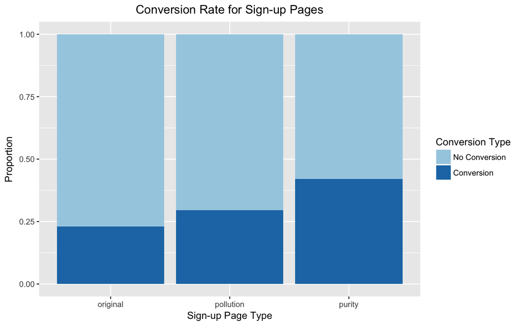

```r
full_data %>%
  ggplot(aes(x = as.factor(pagetype), fill = as.factor(signup))) +
  geom_bar(position = "fill") +
  scale_fill_brewer(name="Conversion Type", palette="Paired", labels=c("No Conversion","Conversion")) +
  theme(plot.title = element_text(hjust = 0.5)) +
  labs(title = "Conversion Rate for Sign-up Pages",
       x = "Sign-up Page Type",
       y = "Proportion")
```

### Pairwise Comparisons

Next we must determine which (if any) of the 3 groups have different conversion rates. To do this we conduct post-hoc Bonferonni (pairwise) comparisons using `pairwise.prop.test()`, which adjusts the p-value of each test to correct for multiple comparisons. Again, groups 1, 2 and 3 correspond to the original, purity and pollution versions of the sign-up page, respectively. Below we see no difference in conversion rates between the original and pollution versions. However, the test version depicting the grassy park (purity) produced significantly more conversions than both the original and pollution versions of the sign-up page.

Based on these results, the original sign-up page with the maple leaf should be replaced by the purity version that depicts the lush green park in the background.

```r
multi_comp <- pairwise.prop.test(full_data_success_rates$success, full_data_success_rates$total,
                                 p.adjust.method = "bonferroni")
multi_comp$p.value
```

```
##              1          2
## 2 0.0002346223         NA
## 3 0.5180253310 0.03685602
```

Before calculating effect size, the number of fails must be counted and placed into the data frame ‘full_data_success_rates’. Moreover, the ‘pagetype’ and ‘total’ variables are removed because they are no longer needed.

```r
full_data_success_rates$fail <- abs(full_data_success_rates$success - full_data_success_rates$total)

full_data_success_rates$pagetype <- NULL
full_data_success_rates$total <- NULL
```

### Effect Size

Even when a statistical test is significant, and the null hypothesis is rejected, the p-value does not reveal the strength of the pattern, or the difference. To find that out, the effect size of the test must be calculated.

The appropriate effect size calculation for the Chi-Square Test of Equal Proportions is the Cramer’s V statistic, which can be seen below. The guidelines set by Cohen (1988) indicates that this is a small effect size, at least within the context of social science research.

```r
k <- 3
r <- 200

cramer_v <- unname(sqrt((chi_test$statistic/600)/min(k - 1, r - 1)))
cramer_v
```

```
## [1] 0.1200227
```

### Power Analysis

When testing for statistical differneces with the Chi-Square Test, whether or not a differnece is significant depends on the number of observations collected—the sample size. If the sample size is too small, then group differences that exist may go undetected. So the question becomes, how do I know if I collected enough data? A power analysis helps answer this question.

The power calculation is related to the sample size, the effect size, the degrees of freedom of the chi-square test. The significance level of the chi-square test is also required. Once you have these values, the power statistic can be calculated, revealing whether or not we have enough data.

A sufficient sample size will yield a power statisitc of at least 0.80. In more conservative cases 0.90 is used. The power of the Chi-square test is 0.75, which is reasonably close to 0.80. This suggests that the 600 observations that were simulated gave the test a reasonable amount of power. Of course, not enough to detect all of the group differences, as each group was specified to have a different proportion when they were simulated.

In a real circumstance, one does not know if differences exist between the groups, so they must rely on domain knolwledge to determine whether how small of group differences they want to detect. A difference that is found when the statistical power is very high may not be of practical significance, or importance, hence the reliance on domain knowledge.

```r
library(pwr)
pwr_chi <- pwr.chisq.test(w = cramer_v, N = 600,
                          df = chi_test$parameter,
                          sig.level = 0.05, power = NULL)
pwr_chi
```

```
##
##      Chi squared power calculation
##
##               w = 0.1200227
##               N = 600
##              df = 2
##       sig.level = 0.05
##           power = 0.7527334
##
## NOTE: N is the number of observations
```

### Logistic Regression

An alternative to using the Chi-Square Test of Equal Proportions is to use logistic regression—a regression model that predicts categorical outcomes. The chi-square test is most appropriate when a single categorical predictor is used, like the version of the sign-up page in this analysis. However, in cases where additional explanatory variables are available, logistic regression should be considered.

In addition to recording the sign-up page version, and whether or not the visitor converted, assume that the user’s ip address was also recorded, which identifies their location. Then we could test whether the effects that were observed in the chi-square test depend on the location of the visitor.

```r
glm_fit <- glm(signup ~ pagetype, data=full_data, family=binomial)
summary(glm_fit)
```

```
##
## Call:
## glm(formula = signup ~ pagetype, family = binomial, data = full_data)
##
## Deviance Residuals:
##     Min       1Q   Median       3Q      Max
## -1.0438  -0.8361  -0.7230   1.3172   1.7145
##
## Coefficients:
##                   Estimate Std. Error z value Pr(>|z|)
## (Intercept)        -1.2083     0.1680  -7.191 6.42e-13 ***
## pagetypepollution   0.3371     0.2286   1.474     0.14
## pagetypepurity      0.8855     0.2208   4.010 6.06e-05 ***
## ---
## Signif. codes:  0 '***' 0.001 '**' 0.01 '*' 0.05 '.' 0.1 ' ' 1
##
## (Dispersion parameter for binomial family taken to be 1)
##
##     Null deviance: 747.65  on 599  degrees of freedom
## Residual deviance: 730.45  on 597  degrees of freedom
## AIC: 736.45
##
## Number of Fisher Scoring iterations: 4
```

### Conclusion

Both the test of equal proportions and the logistic regression produced consistent results, demonstrating ‘toy’ evidence that the company should consider switching the sign-up page from the current version to the one depicting the grassy park. Of course there may be other factors to consider, and other reasons for keeping or updating the sign-up page based on additional AB tests. But according to the insight obtained in this analysis, the grassy park sign-up page should be used for all visitors.